# FE8828 Assignment for Exploratory Data Analysis - UPDATED

Bai Haoyu G1900411H

09 Oct 2019

# Finding #1

This data contains 4521 rows and 17 columns.

# Finding #2

The number of customers in each job group

Managment and blue-collar are the two biggest groups.

```r
# In this finding, I briefly used %>% to get a taste of it
# However, having been used to use the conentional way, I used the the conventional (more tedious) way for the rest of the findings
# I will try to practice more on this operator in my future work
jobgroup <- group_by(bank, job) %>%
  summarise(num = n())

jobgroup
```

```
## # A tibble: 12 x 2
##    job             num
##    <fct>         <int>
##  1 admin.          478
##  2 blue-collar     946
##  3 entrepreneur    168
##  4 housemaid       112
##  5 management      969
##  6 retired         230
##  7 self-employed   183
##  8 services        417
##  9 student          84
## 10 technician      768
## 11 unemployed      128
## 12 unknown          38
```

# Finding #3

The average ages of the customers in each job group

Surprisingly, people on average loose their jobs in early 40’s (so sad)

```r
jobgroup <- group_by(bank, job)
summarise(jobgroup, avg_age = mean(age))
```

```
## # A tibble: 12 x 2
##    job           avg_age
##    <fct>           <dbl>
##  1 admin.           39.7
##  2 blue-collar      40.2
##  3 entrepreneur     42.0
##  4 housemaid        47.3
##  5 management       40.5
##  6 retired          61.9
##  7 self-employed    41.5
##  8 services         38.6
##  9 student          26.8
## 10 technician       39.5
## 11 unemployed       40.9
## 12 unknown          48.1
```

# Finding #4

The number of customers in each age group?

30’s and 40’s are the two biggest groups.

Also the distribution is more dense within 20’s to 50’s, this could be explained by the fact that younger people have less financial needs(like students), and older people tend to use cash

```r
bank_f4 <- mutate(bank, age_group = (age %/% 10) * 10)
agegroup <- group_by(bank_f4, age_group)
summarise(agegroup, num = n())
```

```
## # A tibble: 8 x 2
##   age_group   num
##       <dbl> <int>
## 1        10     4
## 2        20   478
## 3        30  1808
## 4        40  1203
## 5        50   854
## 6        60   113
## 7        70    47
## 8        80    14
```

# Finding #5

Plot the number of unemployeed customer in each age group and Print the unemployment rate:

30’s has the highest unnemployed number. Besides 20’s (students), 40’s have the highest unemployed rate, which is consistent with finding #3

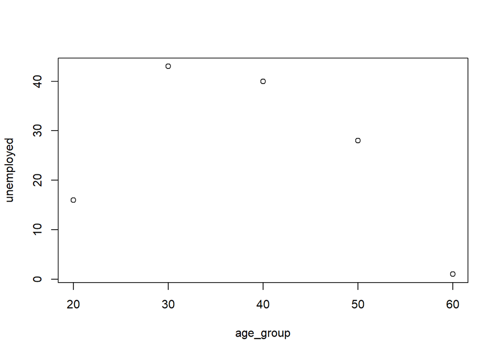

```r
bank_f4 <- mutate(bank, age_group = (age %/% 10) * 10)
agegroup <- group_by(bank_f4, age_group)
agegroup_num <- summarise(agegroup, total = n())

unemployed_age_group <- dplyr::filter(agegroup, job == "unemployed")
grouped_unemployed_age_group <- group_by(unemployed_age_group, age_group)
unemployed_num <- summarise(grouped_unemployed_age_group, unemployed=n())

unemployed_age <- left_join(unemployed_num, agegroup_num, by = "age_group")
unemployed_rate <- mutate(unemployed_age, rate = unemployed/total)

plot(unemployed_num)
```

```r
unemployed_rate
```

```
## # A tibble: 5 x 4
##   age_group unemployed total    rate
##       <dbl>      <int> <int>   <dbl>
## 1        20         16   478 0.0335
## 2        30         43  1808 0.0238
## 3        40         40  1203 0.0333
## 4        50         28   854 0.0328
## 5        60          1   113 0.00885
```

# Finding #6

The number of customer and their avergae balance in each education group?

Looks like the highest education group (tertiary) has the highes balance, but primary group has higher balance than secondary group. One possible explanation is people with only primary education started work ealier and have accumulated more money

```r
educationgroup <- group_by(bank, education)
education_num <- summarise(educationgroup, num = n())
education_balance <- summarise(educationgroup, avg_balance = mean(balance))
education_summary <- left_join(education_num, education_balance, by = "education")

education_summary
```

```
## # A tibble: 4 x 3
##   education   num avg_balance
##   <fct>     <int>       <dbl>
## 1 primary     678       1412.
## 2 secondary  2306       1197.
## 3 tertiary   1350       1775.
## 4 unknown     187       1701.
```

# Finding #7

Which education group has the most number of married customer?

Secondary education has the most number of married customers.

```r
educationgroup <- group_by(bank, education)
married_education <- dplyr::filter(educationgroup, marital == "married")
married_num <- summarize(married_education, married=n())
married_num <- arrange(married_num, desc(married))
married_num
```

```
## # A tibble: 4 x 2
##   education married
##   <fct>       <int>
## 1 secondary    1427
## 2 tertiary      727
## 3 primary       526
## 4 unknown       117
```

# Finding #8

Which job group has the most number of married customer?

Bule-collar has the highest number of married customers. Surprisingly, there are 10 married students…

Can we draw the conclusion that bule-collar has the most number of secondary education customer? Or vice versa? BOTH WE CAN!!!

```r
jobgroup <- group_by(bank, job)
married_job <- dplyr::filter(jobgroup, marital == "married")
married_num <- summarize(married_job, married=n())
married_num <- arrange(married_num, desc(married))
married_num
```

```
## # A tibble: 12 x 2
##    job           married
##    <fct>           <int>
##  1 blue-collar       693
##  2 management        557
##  3 technician        411
##  4 admin.            266
##  5 services          236
##  6 retired           176
##  7 entrepreneur      132
##  8 self-employed     127
##  9 housemaid          84
## 10 unemployed         75
## 11 unknown            30
## 12 student            10
```

```r
# whether bule-collar has the most number of secondary education customer?
jobgroup <- group_by(bank, job)
edu_job <- dplyr::filter(jobgroup, education == "secondary")
edu_num <- summarize(edu_job, secon=n())
edu_num <- arrange(edu_num, desc(secon))
edu_num
```

```
## # A tibble: 12 x 2
##    job           secon
##    <fct>         <int>
##  1 blue-collar     524
##  2 technician      520
##  3 admin.          393
##  4 services        363
##  5 management      116
##  6 retired         105
##  7 self-employed    76
##  8 unemployed       68
##  9 entrepreneur     58
## 10 student          47
## 11 housemaid        28
## 12 unknown           8
```

```r
# vice versa?
edugroup <- group_by(bank, education)
e_job <- dplyr::filter(edugroup, job == "blue-collar")
e_num <- summarize(e_job, j=n())
e_num <- arrange(e_num, desc(j))
e_num
```

```
## # A tibble: 4 x 2
##   education     j
##   <fct>     <int>
## 1 secondary   524
## 2 primary     369
## 3 unknown      41
## 4 tertiary     12
```

# Finding #9

Interesting Fact 1: having a house does not significantly increase the chance of getting married, as the percentages of having a house in each marital status are approximately the same, which is over half. However, having a lower balance may really result in getting divorced. As the Chinese old saying, “Material is the foundamention of love/relationship”. Very insighful and motivational!

```r
maritalgroup <- group_by(bank, marital)
marital_num <- summarise(maritalgroup, total = n())
marital_housing <- dplyr::filter(maritalgroup, housing == "yes")
housing_num <- summarise(marital_housing, with_housing = n())
marital_balance <- summarize(maritalgroup, avg_balance=mean(balance))
marital_summary <- left_join(marital_num, housing_num, by = "marital")
marital_summary <- left_join(marital_summary, marital_balance, by = "marital")

marital_summary
```

```
## # A tibble: 3 x 4
##   marital  total with_housing avg_balance
##   <fct>    <int>        <int>       <dbl>
## 1 divorced   528          298       1122.
## 2 married   2797         1625       1463.
## 3 single    1196          636       1460.
```

# Finding #10

Interesting Fact 2: customers in Age group 40 has the highest ratio of negative balance, which is consistent with ealier findings. All the findigns regarding 40’s lead me to a very scary word: midlife crisis. Seems like I need to prepare early!

```r
bank_f4 <- mutate(bank, age_group = (age %/% 10) * 10)
agegroup <- group_by(bank_f4, age_group)
agegroup_num <- summarise(agegroup, total = n())

negative_age_group <- dplyr::filter(agegroup, balance < 0)
grouped_negative_age_group <- group_by(negative_age_group, age_group)
negative_num <- summarise(grouped_negative_age_group, negative_total=n())

negative_age <- left_join(negative_num, agegroup_num, by = "age_group")
negative_rate <- mutate(negative_age, ratio = negative_total/total)
negative_rate <- arrange(negative_rate, desc(ratio))

negative_rate
```

```
## # A tibble: 5 x 4
##   age_group negative_total total  ratio
##       <dbl>          <int> <int>  <dbl>
## 1        40            116  1203 0.0964
## 2        20             46   478 0.0962
## 3        30            139  1808 0.0769
## 4        50             63   854 0.0738
## 5        60              2   113 0.0177
```